# Assign wolf territories to 50km x 50km grids based on coordinate matching.

This script reads two CSV files:

1. grid_with_counties.csv - Contains grid centroids (centroid_lon, centroid_lat) and grid metadata
2. matched_wolf_territories.csv - Contains wolf territory data with Latitude and Longitude

For each grid, if a wolf territory's coordinates fall within the 50km x 50km area centered on the grid's centroid, that territory's information is added to the grid.

Output: Updated grid file with three new columns containing lists of matching territories.

```python
#!/usr/bin/env python3
"""
Wolf Territory Distribution by Grid with 6-Year Persistence Rule

This script assigns wolf territories to 50km x 50km grids and implements
a persistence rule: once a territory is observed in a grid, it persists
for 6 consecutive years total. If a territory has been tracked for N years
consecutively, it will be extended for (6 - N) additional years from the
last observed year.

Author: Updated version with persistence rule
Date: December 2024
"""

import csv
import math
import os
from collections import defaultdict

# =============================================================================
# STEP 1: DEFINE FILE PATHS
# =============================================================================
# Input file paths
grid_file = r"C:\Users\sinch\OneDrive\Desktop\data_14_12\grid_with_counties.csv"
territories_file = r"C:\Users\sinch\OneDrive\Desktop\data_14_12\matched_wolf_territories.csv"

# Output file path
output_file = r"C:\Users\sinch\OneDrive\Desktop\data_14_12\grid_with_territories.csv"


# =============================================================================
# STEP 2: DEFINE PERSISTENCE PARAMETERS
# =============================================================================
# Number of years a territory should persist after first observation
PERSISTENCE_YEARS = 6


# =============================================================================
# STEP 3: DEFINE HELPER FUNCTION TO CALCULATE DISTANCE BETWEEN TWO COORDINATES
# =============================================================================
def haversine_distance(lat1, lon1, lat2, lon2):
    """
    Calculate the great-circle distance between two points on Earth
    using the Haversine formula.

    Parameters:
        lat1, lon1: Latitude and Longitude of point 1 (in degrees)
        lat2, lon2: Latitude and Longitude of point 2 (in degrees)

    Returns:
        Distance in kilometers between the two points

    Note: This function is used to determine if a territory falls within
          the 50km x 50km grid area around a centroid.
    """
    # Earth's radius in kilometers
    R = 6371.0

    # Convert degrees to radians
    lat1_rad = math.radians(lat1)
    lat2_rad = math.radians(lat2)
    lon1_rad = math.radians(lon1)
    lon2_rad = math.radians(lon2)

    # Differences in coordinates
    dlat = lat2_rad - lat1_rad
    dlon = lon2_rad - lon1_rad

    # Haversine formula
    a = math.sin(dlat / 2)**2 + math.cos(lat1_rad) * math.cos(lat2_rad) * math.sin(dlon / 2)**2
    c = 2 * math.atan2(math.sqrt(a), math.sqrt(1 - a))

    # Distance in kilometers
    distance = R * c

    return distance


# =============================================================================
# STEP 4: DEFINE FUNCTION TO CHECK IF A POINT FALLS WITHIN A 50KM x 50KM GRID
# =============================================================================
def is_point_in_grid(point_lat, point_lon, centroid_lat, centroid_lon, grid_size_km=50):
    """
    Check if a point (lat, lon) falls within a square grid centered on the centroid.

    The grid is defined as a 50km x 50km square, meaning the point must be:
    - Within 25km north or south of the centroid (latitude direction)
    - Within 25km east or west of the centroid (longitude direction)

    Parameters:
        point_lat, point_lon: Coordinates of the point to check (wolf territory)
        centroid_lat, centroid_lon: Coordinates of the grid centroid
        grid_size_km: Size of the grid in km (default 50km, so half-size is 25km)

    Returns:
        True if the point is within the grid, False otherwise
    """
    half_grid = grid_size_km / 2  # 25 km from centroid to edge

    # Calculate the north-south distance (along latitude)
    ns_distance = haversine_distance(point_lat, centroid_lon, centroid_lat, centroid_lon)

    # Calculate the east-west distance (along longitude)
    ew_distance = haversine_distance(centroid_lat, point_lon, centroid_lat, centroid_lon)

    # Check if both distances are within half the grid size (25 km)
    return ns_distance <= half_grid and ew_distance <= half_grid


# =============================================================================
# STEP 5: READ THE GRID FILE
# =============================================================================
print("Step 5: Reading grid file...")

grid_data = []

with open(grid_file, 'r', encoding='utf-8') as f:
    reader = csv.DictReader(f)
    grid_headers = reader.fieldnames  # Store original headers

    for row in reader:
        # Convert centroid coordinates to float for calculations
        row['centroid_lat_float'] = float(row['centroid_lat'])
        row['centroid_lon_float'] = float(row['centroid_lon'])
        grid_data.append(row)

print(f"  Loaded {len(grid_data)} grid rows")


# =============================================================================
# STEP 6: READ THE WOLF TERRITORIES FILE
# =============================================================================
print("Step 6: Reading wolf territories file...")

territories_data = []

with open(territories_file, 'r', encoding='utf-8') as f:
    reader = csv.DictReader(f)

    for row in reader:
        # Convert coordinates to float for calculations
        row['lat_float'] = float(row['Latitude'])
        row['lon_float'] = float(row['Longitude'])
        # Convert years to integers
        row['start_year_int'] = int(row['Start_Year'])
        row['end_year_int'] = int(row['End_Year'])

        territories_data.append(row)

print(f"  Loaded {len(territories_data)} territory rows")


# =============================================================================
# STEP 7: BUILD TERRITORY-GRID MAPPING WITH YEAR TRACKING
# =============================================================================
print("Step 7: Building territory-grid mapping with year tracking...")

# Data structure to track territory observations per grid:
# grid_territory_years[GridID][Territory_Name] = {
#     'observed_years': set(),      # Years when territory was actually observed
#     'territory_size': value,      # Most recent territory size
#     'pack_size': value,           # Most recent pack size
#     'first_observed': year,       # First year observed in this grid
#     'last_observed': year         # Last year observed in this grid
# }
grid_territory_years = defaultdict(lambda: defaultdict(lambda: {
    'observed_years': set(),
    'territory_size': None,
    'pack_size': None,
    'first_observed': None,
    'last_observed': None
}))
```

```python
# Create a mapping of GridID to grid data for quick lookup
grid_id_to_index = {grid['GridID']: idx for idx, grid in enumerate(grid_data)}

# For each territory record, find which grid it belongs to and track years
for territory in territories_data:
    terr_lat = territory['lat_float']
    terr_lon = territory['lon_float']
    terr_name = territory['Territory']
    terr_size = territory['Territory_Size_km2']
    pack_size = territory['Pack_Size']
    start_year = territory['start_year_int']
    end_year = territory['end_year_int']

    # Generate the list of years this territory was observed
    # (from Start_Year to End_Year inclusive)
    observed_years = set(range(start_year, end_year + 1))

    # Check against each grid
    for grid in grid_data:
        centroid_lat = grid['centroid_lat_float']
        centroid_lon = grid['centroid_lon_float']
        grid_id = grid['GridID']

        # Check if this territory falls within this grid
        if is_point_in_grid(terr_lat, terr_lon, centroid_lat, centroid_lon, grid_size_km=50):
            # Update the tracking data for this territory in this grid
            terr_data = grid_territory_years[grid_id][terr_name]

            # Add observed years
            terr_data['observed_years'].update(observed_years)

            # Update territory size and pack size (use most recent values)
            terr_data['territory_size'] = terr_size
            terr_data['pack_size'] = pack_size

            # Update first and last observed years
            min_year = min(observed_years)
            max_year = max(observed_years)

            if terr_data['first_observed'] is None or min_year < terr_data['first_observed']:
                terr_data['first_observed'] = min_year

            if terr_data['last_observed'] is None or max_year > terr_data['last_observed']:
                terr_data['last_observed'] = max_year

print(f"  Processed {len(grid_territory_years)} grids with territory assignments")


# =============================================================================
# STEP 8: APPLY 6-YEAR PERSISTENCE RULE
# =============================================================================
print("Step 8: Applying 6-year persistence rule...")

# For each grid and territory, calculate the extended years based on persistence rule
#
# Logic:
# 1. Count consecutive years from first observation
# 2. If consecutive years < 6, extend to make total = 6 years from first observation
# 3. The extension starts from the last observed year
#
# Example:
# - Territory observed in 2010, 2011, 2012 (3 consecutive years)
# - Needs 6 - 3 = 3 more years
# - Will be present in: 2010, 2011, 2012, 2013, 2014, 2015 (6 total)

def count_consecutive_years_from_start(observed_years, first_year):
    """
    Count how many consecutive years the territory was observed
    starting from its first observation year.

    Parameters:
        observed_years: Set of years when territory was observed
        first_year: The first year of observation

    Returns:
        Number of consecutive years from first observation
    """
    consecutive = 0
    year = first_year
    while year in observed_years:
        consecutive += 1
        year += 1
    return consecutive


def calculate_extended_years(observed_years, first_observed, last_observed, persistence=6):
    """
    Calculate the full set of years a territory should appear in output,
    applying the persistence rule.

    Parameters:
        observed_years: Set of years when territory was actually observed
        first_observed: First year of observation
        last_observed: Last year of observation
        persistence: Number of years territory should persist (default 6)

    Returns:
        Set of years including both observed and extended years

    Logic:
        - Count consecutive years from first observation
        - If less than persistence years, extend from last observed year
        - Total years in output = max(consecutive observed, persistence from first)
    """
    # Count consecutive years from the first observation
    consecutive_count = count_consecutive_years_from_start(observed_years, first_observed)

    # Calculate how many additional years are needed
    years_to_add = persistence - consecutive_count

    # Start with all observed years
    extended_years = set(observed_years)

    # If we need to add more years, extend from the last observed year
    if years_to_add > 0:
        for i in range(1, years_to_add + 1):
            extended_years.add(last_observed + i)

    return extended_years


# Apply persistence rule to all territories in all grids
# Store the final year sets for each territory in each grid
grid_territory_final_years = defaultdict(lambda: defaultdict(dict))

for grid_id, territories in grid_territory_years.items():
    for terr_name, terr_data in territories.items():
        observed = terr_data['observed_years']
        first = terr_data['first_observed']
        last = terr_data['last_observed']

        # Calculate extended years with persistence rule
        final_years = calculate_extended_years(observed, first, last, PERSISTENCE_YEARS)

        grid_territory_final_years[grid_id][terr_name] = {
            'years': final_years,
            'observed_years': observed,
            'territory_size': terr_data['territory_size'],
            'pack_size': terr_data['pack_size'],
            'first_observed': first,
            'last_observed': last
        }

print(f"  Applied persistence rule to all territory-grid combinations")


# =============================================================================
# STEP 9: DETERMINE THE RANGE OF YEARS FOR OUTPUT
# =============================================================================
print("Step 9: Determining year range for output...")

# Find the minimum and maximum years across all extended territory data
all_years = set()
for grid_id, territories in grid_territory_final_years.items():
    for terr_name, terr_data in territories.items():
        all_years.update(terr_data['years'])
```

```python
min_year = min(all_years) if all_years else None
max_year = max(all_years) if all_years else None

print(f"  Year range: {min_year} to {max_year}")


# =============================================================================
# STEP 10: BUILD OUTPUT DATA STRUCTURE
# =============================================================================
print("Step 10: Building output data structure...")

# For the output, we need to create lists per grid that include:
# - All territories that should be present (based on persistence rule)
# - Along with their sizes and pack sizes

# Initialize output data for each grid
for grid in grid_data:
    grid['Territory_list'] = []
    grid['Territory_size_list'] = []
    grid['Pack_Size_list'] = []

# We need to decide: should the output be aggregated across all years,
# or should we create separate output files per year?
#
# Based on your original code structure, it seems like a single output file
# with aggregated data. The territories listed will be those that should
# be present based on the 6-year persistence rule.
#
# Alternative interpretation: If you want year-by-year output files,
# please let me know and I can modify this section.

# For now, aggregating all territories (with persistence applied) into single output:
for grid in grid_data:
    grid_id = grid['GridID']

    if grid_id in grid_territory_final_years:
        for terr_name, terr_data in grid_territory_final_years[grid_id].items():
            grid['Territory_list'].append(terr_name)
            grid['Territory_size_list'].append(terr_data['territory_size'])
            grid['Pack_Size_list'].append(terr_data['pack_size'])


# =============================================================================
# STEP 11: COUNT GRIDS WITH TERRITORIES ASSIGNED
# =============================================================================
print("Step 11: Summarizing results...")

grids_with_territories = sum(1 for grid in grid_data if grid['Territory_list'])

print(f"  Grids with at least one territory: {grids_with_territories}")
print(f"  Grids without any territories: {len(grid_data) - grids_with_territories}")


# =============================================================================
# STEP 12: PREPARE OUTPUT - CONVERT LISTS TO STRING REPRESENTATION
# =============================================================================
print("Step 12: Preparing output data...")

for grid in grid_data:
    # Convert Territory_list to string representation
    if grid['Territory_list']:
        grid['Territory_list'] = '[' + ', '.join(f'"{t}"' for t in grid['Territory_list']) + ']'
    else:
        grid['Territory_list'] = '[]'

    # Convert Territory_size_list to string representation
    if grid['Territory_size_list']:
        grid['Territory_size_list'] = '[' + ', '.join(str(s) for s in grid['Territory_size_list']) + ']'
    else:
        grid['Territory_size_list'] = '[]'

    # Convert Pack_Size_list to string representation
    if grid['Pack_Size_list']:
        grid['Pack_Size_list'] = '[' + ', '.join(str(p) for p in grid['Pack_Size_list']) + ']'
    else:
        grid['Pack_Size_list'] = '[]'


# =============================================================================
# STEP 13: WRITE OUTPUT FILE
# =============================================================================
print(f"Step 13: Writing output to {output_file}...")

# Define output columns
output_columns = list(grid_headers) + ['Territory_list', 'Territory_size_list', 'Pack_Size_list']

with open(output_file, 'w', newline='', encoding='utf-8') as f:
    writer = csv.DictWriter(f, fieldnames=output_columns, extrasaction='ignore')
    writer.writeheader()

    for grid in grid_data:
        writer.writerow(grid)

print(f"  Output file written successfully!")


# =============================================================================
# STEP 14: PRINT DETAILED PERSISTENCE EXAMPLES FOR VERIFICATION
# =============================================================================
print("\nStep 14: Examples of persistence rule application:")
print("-" * 100)

example_count = 0
for grid_id, territories in grid_territory_final_years.items():
    for terr_name, terr_data in territories.items():
        observed = sorted(terr_data['observed_years'])
        final = sorted(terr_data['years'])

        # Only show examples where extension was applied
        if len(final) > len(observed):
            print(f"Grid: {grid_id}, Territory: {terr_name}")
            print(f"  First observed: {terr_data['first_observed']}")
            print(f"  Last observed: {terr_data['last_observed']}")
            print(f"  Actually observed years: {observed}")
            print(f"  Final years (with persistence): {final}")
            print(f"  Extended by {len(final) - len(observed)} years")
            print()
            example_count += 1
            if example_count >= 5:
                break
    if example_count >= 5:
        break


# =============================================================================
# STEP 15: PRINT SAMPLE OUTPUT FOR VERIFICATION
# =============================================================================
print("\nStep 15: Sample output (first 5 grids with territories):")
print("-" * 100)

sample_count = 0
for grid in grid_data:
    if grid['Territory_list'] != '[]':
        print(f"GridID: {grid['GridID']}")
        print(f"  Centroid: ({grid['centroid_lat']}, {grid['centroid_lon']})")
        print(f"  County: {grid['County_Identified']}, Country: {grid['Country_Identified']}")
        print(f"  Territory_list: {grid['Territory_list']}")
        print(f"  Territory_size_list: {grid['Territory_size_list']}")
        print(f"  Pack_Size_list: {grid['Pack_Size_list']}")
        print()
        sample_count += 1
        if sample_count >= 5:
            break

print("=" * 100)
print("Script completed successfully!")
print(f"\nNote: Territories persist for {PERSISTENCE_YEARS} consecutive years from first observation.")
print("If a territory was observed for fewer consecutive years, it is extended to meet the 6-year rule.")
```

```
Step 5: Reading grid file...
  Loaded 431 grid rows
Step 6: Reading wolf territories file...
  Loaded 93 territory rows
Step 7: Building territory-grid mapping with year tracking...
  Processed 28 grids with territory assignments
Step 8: Applying 6-year persistence rule...
  Applied persistence rule to all territory-grid combinations
Step 9: Determining year range for output...
  Year range: 1999 to 2025
Step 10: Building output data structure...
Step 11: Summarizing results...
  Grids with at least one territory: 28
  Grids without any territories: 403
Step 12: Preparing output data...
Step 13: Writing output to C:\Users\sinch\OneDrive\Desktop\data_14_12\grid_with_territories.csv...
  Output file written successfully!

Step 14: Examples of persistence rule application:
----------------------------------------------------------------------------------------------------
Grid: 176, Territory: Aamack
  First observed: 2008
  Last observed: 2014
  Actually observed years: [2008, 2009, 2013, 2014]
  Final years (with persistence): [2008, 2009, 2013, 2014, 2015, 2016, 2017, 2018]
  Extended by 4 years

Grid: 176, Territory: Tyngsjo
  First observed: 2001
  Last observed: 2002
  Actually observed years: [2001, 2002]
  Final years (with persistence): [2001, 2002, 2003, 2004, 2005, 2006]
  Extended by 4 years

Grid: 254, Territory: Amungen
  First observed: 2005
  Last observed: 2007
  Actually observed years: [2005, 2006, 2007]
  Final years (with persistence): [2005, 2006, 2007, 2008, 2009, 2010]
  Extended by 3 years
```

[output cut: 43 more lines]

```
  Territory_size_list: [363.72098520000003, 1441.2482029999999, 2025.074689]
  Pack_Size_list: [9, 2, 1]

GridID: 107
  Centroid: (60.1026869, 11.97505513)
  County: Hedmark, Country: Norway
  Territory_list: ["Mangen"]
  Territory_size_list: [632.4153527]
  Pack_Size_list: [4]

====================================================================================================
Script completed successfully!

Note: Territories persist for 6 consecutive years from first observation.
If a territory was observed for fewer consecutive years, it is extended to meet the 6-year rule.
```

# Wolf Territory Distribution by Grid

This script reads wolf territory data and grid data, then assigns wolf territories to 50km x 50km grids based on whether the territory's latitude/longitude falls within the grid cell centered at the grid's centroid.

Input files:

- matched_wolf_territories.csv: Contains territory locations with Start_Year, End_Year
- grid_with_counties.csv: Contains grid centroids with 50km x 50km cells

Output:

- Wolf_distribution_YYYY.csv files for each year in the data range

```python
import csv
import math
import os
from collections import defaultdict

# =============================================================================
# STEP 1: DEFINE FILE PATHS
# =============================================================================
print("=" * 100)
print("WOLF TERRITORY DISTRIBUTION BY GRID - WITH 6-YEAR PERSISTENCE RULE")
print("=" * 100)

print("\n" + "-" * 100)
print("STEP 1: DEFINING FILE PATHS")
print("-" * 100)

# Input file paths
grid_file = r"C:\Users\sinch\OneDrive\Desktop\data_14_12\grid_with_counties.csv"
territories_file = r"C:\Users\sinch\OneDrive\Desktop\data_14_12\matched_wolf_territories.csv"

# Output folder path
output_folder = r"C:\Users\sinch\OneDrive\Desktop\data_14_12\Wolf distribution"

print(f"  Grid file:        {grid_file}")
print(f"  Territories file: {territories_file}")
print(f"  Output folder:    {output_folder}")


# =============================================================================
# STEP 2: DEFINE PERSISTENCE PARAMETERS
# =============================================================================
print("\n" + "-" * 100)
print("STEP 2: DEFINING PERSISTENCE PARAMETERS")
print("-" * 100)

# Number of years a territory should persist AFTER each observation
# (including the observation year itself)
# So if observed in 2005, territory appears in 2005, 2006, 2007, 2008, 2009, 2010
PERSISTENCE_YEARS = 6

print(f"  Persistence years: {PERSISTENCE_YEARS}")
print(f"  This means: If a territory is observed in year Y, it will appear in")
print(f"              years Y, Y+1, Y+2, Y+3, Y+4, Y+5 (total {PERSISTENCE_YEARS} years)")


# =============================================================================
# STEP 3: DEFINE HELPER FUNCTION TO CALCULATE DISTANCE BETWEEN TWO COORDINATES
# =============================================================================
print("\n" + "-" * 100)
print("STEP 3: DEFINING HAVERSINE DISTANCE FUNCTION")
print("-" * 100)
print("  This function calculates the great-circle distance between two points")
print("  on Earth's surface using the Haversine formula.")
print("  Used to determine if a territory falls within a 50km x 50km grid.")

def haversine_distance(lat1, lon1, lat2, lon2):
    """
    Calculate the great-circle distance between two points on Earth
    using the Haversine formula.

    Parameters:
        lat1, lon1: Latitude and Longitude of point 1 (in degrees)
        lat2, lon2: Latitude and Longitude of point 2 (in degrees)

    Returns:
        Distance in kilometers between the two points
    """
    R = 6371.0  # Earth's radius in kilometers

    lat1_rad = math.radians(lat1)
    lat2_rad = math.radians(lat2)
    lon1_rad = math.radians(lon1)
    lon2_rad = math.radians(lon2)

    dlat = lat2_rad - lat1_rad
    dlon = lon2_rad - lon1_rad

    a = math.sin(dlat / 2)**2 + math.cos(lat1_rad) * math.cos(lat2_rad) * math.sin(dlon / 2)**2
    c = 2 * math.atan2(math.sqrt(a), math.sqrt(1 - a))

    return R * c

print("  Function defined: haversine_distance(lat1, lon1, lat2, lon2) -> km")


# =============================================================================
# STEP 4: DEFINE FUNCTION TO CHECK IF A POINT FALLS WITHIN A 50KM x 50KM GRID
# =============================================================================
print("\n" + "-" * 100)
print("STEP 4: DEFINING GRID MEMBERSHIP FUNCTION")
print("-" * 100)
print("  This function checks if a point (wolf territory location) falls within")
print("  a 50km x 50km grid cell centered on a given centroid.")
print("  The point must be within 25km in both N-S and E-W directions.")

def is_point_in_grid(point_lat, point_lon, centroid_lat, centroid_lon, grid_size_km=50):
    """
    Check if a point (lat, lon) falls within a square grid centered on the centroid.

    The grid is defined as a 50km x 50km square, meaning the point must be:
    - Within 25km north or south of the centroid (latitude direction)
    - Within 25km east or west of the centroid (longitude direction)

    Returns:
        True if the point is within the grid, False otherwise
    """
    half_grid = grid_size_km / 2  # 25 km from centroid to edge

    ns_distance = haversine_distance(point_lat, centroid_lon, centroid_lat, centroid_lon)
    ew_distance = haversine_distance(centroid_lat, point_lon, centroid_lat, centroid_lon)

    return ns_distance <= half_grid and ew_distance <= half_grid

print("  Function defined: is_point_in_grid(point_lat, point_lon, centroid_lat, centroid_lon) -> True/False")


# =============================================================================
# STEP 5: READ THE GRID FILE
# =============================================================================
print("\n" + "-" * 100)
print("STEP 5: READING GRID FILE")
print("-" * 100)
print(f"  Opening: {grid_file}")

grid_data = []

with open(grid_file, 'r', encoding='utf-8') as f:
    reader = csv.DictReader(f)
    grid_headers = reader.fieldnames  # Store original headers

    print(f"  Columns found: {grid_headers}")

    for row in reader:
        row['centroid_lat_float'] = float(row['centroid_lat'])
        row['centroid_lon_float'] = float(row['centroid_lon'])
        grid_data.append(row)

print(f"\n  SUCCESS: Loaded {len(grid_data)} grid cells")
print(f"  Each grid cell is a 50km x 50km area identified by GridID")

# Show sample grid data
print(f"\n  Sample grid cells (first 3):")
for i, grid in enumerate(grid_data[:3]):
    print(f"    Grid {i+1}: GridID={grid['GridID']}, "
          f"Centroid=({grid['centroid_lat']}, {grid['centroid_lon']}), "
          f"County={grid.get('County_Identified', 'N/A')}")


# =============================================================================
# STEP 6: READ THE WOLF TERRITORIES FILE
# =============================================================================
print("\n" + "-" * 100)
print("STEP 6: READING WOLF TERRITORIES FILE")
print("-" * 100)
print(f"  Opening: {territories_file}")

territories_data = []

with open(territories_file, 'r', encoding='utf-8') as f:
    reader = csv.DictReader(f)
    territories_headers = reader.fieldnames
```

```python
    print(f"  Columns found: {territories_headers}")

    for row in reader:
        row['lat_float'] = float(row['Latitude'])
        row['lon_float'] = float(row['Longitude'])
        row['start_year_int'] = int(row['Start_Year'])
        row['end_year_int'] = int(row['End_Year'])
        territories_data.append(row)

print(f"\n  SUCCESS: Loaded {len(territories_data)} territory records")

# Show sample territory data
print(f"\n  Sample territories (first 5):")
for i, terr in enumerate(territories_data[:5]):
    print(f"    {i+1}. {terr['Territory']}: Years {terr['Start_Year']}-{terr['End_Year']}, "
          f"Location=({terr['Latitude']}, {terr['Longitude']}), "
          f"Pack Size={terr['Pack_Size']}")

# Show year range in original data
all_start_years = [t['start_year_int'] for t in territories_data]
all_end_years = [t['end_year_int'] for t in territories_data]
print(f"\n  Original data year range: {min(all_start_years)} to {max(all_end_years)}")


# =============================================================================
# STEP 7: BUILD TERRITORY-GRID MAPPING WITH YEAR TRACKING
# =============================================================================
print("\n" + "-" * 100)
print("STEP 7: MATCHING TERRITORIES TO GRIDS")
print("-" * 100)
print("  For each territory, checking which 50km grid(s) it falls into...")
print("  A territory falls into a grid if its coordinates are within 25km of the grid centroid.")

# Data structure to track territory observations per grid:
# grid_territory_data[GridID][Territory_Name] = {
#     'observed_years': set(),      # Years when territory was actually observed
#     'territory_size': value,      # Territory size (most recent)
#     'pack_size': value,           # Pack size (most recent)
# }
grid_territory_data = defaultdict(lambda: defaultdict(lambda: {
    'observed_years': set(),
    'territory_size': None,
    'pack_size': None,
}))

# Track matching statistics
total_matches = 0
territories_matched = set()
grids_with_matches = set()

# For each territory record, find which grid it belongs to and track years
print(f"\n  Processing {len(territories_data)} territory records against {len(grid_data)} grids...")

for idx, territory in enumerate(territories_data):
    terr_lat = territory['lat_float']
    terr_lon = territory['lon_float']
    terr_name = territory['Territory']
    terr_size = territory['Territory_Size_km2']
    pack_size = territory['Pack_Size']
    start_year = territory['start_year_int']
    end_year = territory['end_year_int']

    # Generate the list of years this territory was observed
    # Each year from Start_Year to End_Year is an observation year
    observed_years = set(range(start_year, end_year + 1))

    # Check against each grid
    matches_for_this_territory = 0
    for grid in grid_data:
        centroid_lat = grid['centroid_lat_float']
        centroid_lon = grid['centroid_lon_float']
        grid_id = grid['GridID']

        if is_point_in_grid(terr_lat, terr_lon, centroid_lat, centroid_lon, grid_size_km=50):
            terr_data = grid_territory_data[grid_id][terr_name]

            # Add observed years
            terr_data['observed_years'].update(observed_years)

            # Update territory size and pack size (use most recent values)
            terr_data['territory_size'] = terr_size
            terr_data['pack_size'] = pack_size

            total_matches += 1
            matches_for_this_territory += 1
            territories_matched.add(terr_name)
            grids_with_matches.add(grid_id)

    # Progress indicator every 20 territories
    if (idx + 1) % 20 == 0 or idx == len(territories_data) - 1:
        print(f"    Processed {idx + 1}/{len(territories_data)} territories...")

print(f"\n  MATCHING COMPLETE:")
print(f"    Total territory-grid matches: {total_matches}")
print(f"    Unique territories matched: {len(territories_matched)}")
print(f"    Grids with at least one territory: {len(grids_with_matches)}")

# Show some example matches
print(f"\n  Example matches (first 5 grids with territories):")
example_count = 0
for grid_id, territories in grid_territory_data.items():
    if example_count >= 5:
        break
    terr_names = list(territories.keys())
    print(f"    Grid {grid_id}: {len(terr_names)} territories - {terr_names[:3]}{'...' if len(terr_names) > 3 else ''}")
    example_count += 1


# =============================================================================
# STEP 8: APPLY CORRECTED 6-YEAR PERSISTENCE RULE
# =============================================================================
print("\n" + "-" * 100)
print("STEP 8: APPLYING 6-YEAR PERSISTENCE RULE")
print("-" * 100)
print("  RULE: For each year Y when a territory is observed, it will appear in")
print(f"        output for years Y, Y+1, Y+2, Y+3, Y+4, Y+5 ({PERSISTENCE_YEARS} years total)")
print("  If observed multiple times, persistence windows ACCUMULATE.")

def calculate_persistence_years(observed_years, persistence=6):
    """
    Calculate all years a territory should appear based on persistence rule.

    For EACH observed year Y, the territory persists for 'persistence' years:
    Y, Y+1, Y+2, ..., Y+(persistence-1)

    Parameters:
        observed_years: Set of years when territory was actually observed
        persistence: Number of years to persist from each observation (default 6)

    Returns:
        Set of all years the territory should appear (observed + persisted)
    """
    all_years = set()

    for obs_year in observed_years:
        # Add this observation year plus the next (persistence-1) years
        for i in range(persistence):
            all_years.add(obs_year + i)

    return all_years


# Apply persistence rule and store final years for each territory in each grid
grid_territory_final = defaultdict(lambda: defaultdict(dict))

print(f"\n  Processing {len(grid_territory_data)} grids...")

total_territory_grid_pairs = 0
for grid_id, territories in grid_territory_data.items():
    for terr_name, terr_data in territories.items():
        observed = terr_data['observed_years']
```

```python
        # Calculate all years with persistence applied
        persistence_years = calculate_persistence_years(observed, PERSISTENCE_YEARS)

        grid_territory_final[grid_id][terr_name] = {
            'persistence_years': persistence_years,
            'observed_years': observed,
            'territory_size': terr_data['territory_size'],
            'pack_size': terr_data['pack_size'],
        }
        total_territory_grid_pairs += 1

print(f"  Applied persistence rule to {total_territory_grid_pairs} territory-grid combinations")

# Show detailed examples of persistence rule application
print(f"\n  DETAILED EXAMPLES OF PERSISTENCE RULE:")
print("  " + "-" * 80)
example_count = 0
for grid_id, territories in grid_territory_final.items():
    for terr_name, terr_data in territories.items():
        observed = sorted(terr_data['observed_years'])
        final = sorted(terr_data['persistence_years'])

        print(f"\n  Example {example_count + 1}:")
        print(f"    Grid: {grid_id}, Territory: {terr_name}")
        print(f"    Actually OBSERVED in years: {observed}")
        print(f"    Applying persistence rule:")
        for obs_year in observed:
            extended = [obs_year + i for i in range(PERSISTENCE_YEARS)]
            print(f"      Observation {obs_year} → persists to {extended}")
        print(f"    FINAL years in output: {final}")
        print(f"    Result: Observed {len(observed)} years → Present for {len(final)} years")

        example_count += 1
        if example_count >= 3:
            break
    if example_count >= 3:
        break


# =============================================================================
# STEP 9: DETERMINE THE RANGE OF YEARS FOR OUTPUT FILES
# =============================================================================
print("\n" + "-" * 100)
print("STEP 9: DETERMINING OUTPUT YEAR RANGE")
print("-" * 100)

# Collect all years that have at least one territory present
all_years = set()
for grid_id, territories in grid_territory_final.items():
    for terr_name, terr_data in territories.items():
        all_years.update(terr_data['persistence_years'])

min_year = min(all_years) if all_years else None
max_year = max(all_years) if all_years else None
year_range = sorted(all_years)

print(f"  Earliest year with territories: {min_year}")
print(f"  Latest year with territories: {max_year}")
print(f"  Total years to generate: {len(year_range)}")
print(f"  Years: {year_range}")


# =============================================================================
# STEP 10: CREATE OUTPUT FOLDER
# =============================================================================
print("\n" + "-" * 100)
print("STEP 10: CREATING OUTPUT FOLDER")
print("-" * 100)

if not os.path.exists(output_folder):
    os.makedirs(output_folder)
    print(f"  Created new folder: {output_folder}")
else:
    print(f"  Folder already exists: {output_folder}")


# =============================================================================
# STEP 11: BUILD YEARLY TERRITORY DATA AND WRITE OUTPUT FILES
# =============================================================================
print("\n" + "-" * 100)
print("STEP 11: GENERATING YEARLY OUTPUT FILES")
print("-" * 100)
print(f"  Will create {len(year_range)} CSV files, one for each year from {min_year} to {max_year}")
print(f"  Each file will contain all {len(grid_data)} grids with their assigned territories for that year")

# Define output columns
output_columns = list(grid_headers) + ['Territory_list', 'Territory_size_list', 'Pack_Size_list']
print(f"\n  Output columns: {output_columns}")

# Track statistics
total_files_written = 0
yearly_stats = {}  # year -> count of grids with territories
yearly_territory_counts = {}  # year -> total number of territory entries

print(f"\n  Processing each year...")
print("  " + "-" * 80)

# Process each year
for year in year_range:
    # Create a fresh copy of grid data for this year
    year_grid_data = []
    total_territories_this_year = 0
    grids_with_territories_this_year = 0

    for grid in grid_data:
        # Create a copy of the grid row
        grid_copy = dict(grid)
        grid_id = grid['GridID']

        # Initialize territory lists for this grid and year
        territory_list = []
        territory_size_list = []
        pack_size_list = []

        # Check if this grid has any territories
        if grid_id in grid_territory_final:
            for terr_name, terr_data in grid_territory_final[grid_id].items():
                # Check if this territory should be present in this year
                if year in terr_data['persistence_years']:
                    territory_list.append(terr_name)
                    territory_size_list.append(terr_data['territory_size'])
                    pack_size_list.append(terr_data['pack_size'])
                    total_territories_this_year += 1

        # Convert lists to string representation
        if territory_list:
            grid_copy['Territory_list'] = '[' + ', '.join(f'"{t}"' for t in territory_list) + ']'
            grid_copy['Territory_size_list'] = '[' + ', '.join(str(s) for s in territory_size_list) + ']'
            grid_copy['Pack_Size_list'] = '[' + ', '.join(str(p) for p in pack_size_list) + ']'
            grids_with_territories_this_year += 1
        else:
            grid_copy['Territory_list'] = '[]'
            grid_copy['Territory_size_list'] = '[]'
            grid_copy['Pack_Size_list'] = '[]'

        year_grid_data.append(grid_copy)

    # Store statistics
    yearly_stats[year] = grids_with_territories_this_year
    yearly_territory_counts[year] = total_territories_this_year

    # Write output file for this year
    output_file = os.path.join(output_folder, f"Wolf_distribution_{year}.csv")

    with open(output_file, 'w', newline='', encoding='utf-8') as f:
        writer = csv.DictWriter(f, fieldnames=output_columns, extrasaction='ignore')
        writer.writeheader()

        for grid_row in year_grid_data:
            writer.writerow(grid_row)
```

```python
    total_files_written += 1

    # Print progress for this year
    print(f"  Year {year}: Written Wolf_distribution_{year}.csv")
    print(f"           → {grids_with_territories_this_year} grids have territories, "
          f"{total_territories_this_year} total territory entries")


# =============================================================================
# STEP 12: PRINT SUMMARY STATISTICS
# =============================================================================
print("\n" + "=" * 100)
print("FINAL SUMMARY")
print("=" * 100)

print(f"\n  OUTPUT FILES:")
print(f"    Total files written: {total_files_written}")
print(f"    Output folder: {output_folder}")
print(f"    File naming: Wolf_distribution_YYYY.csv")

print(f"\n  YEAR-BY-YEAR STATISTICS:")
print("  " + "-" * 70)
print(f"  {'Year':<8} {'Grids with Territories':<25} {'Total Territory Entries':<25}")
print("  " + "-" * 70)
for year in sorted(yearly_stats.keys()):
    print(f"  {year:<8} {yearly_stats[year]:<25} {yearly_territory_counts[year]:<25}")

# Calculate trends
years_sorted = sorted(yearly_stats.keys())
if len(years_sorted) > 1:
    first_half = years_sorted[:len(years_sorted)//2]
    second_half = years_sorted[len(years_sorted)//2:]

    first_half_avg = sum(yearly_territory_counts[y] for y in first_half) / len(first_half)
    second_half_avg = sum(yearly_territory_counts[y] for y in second_half) / len(second_half)

    print(f"\n  TREND ANALYSIS:")
    print(f"    Average territories in first half ({first_half[0]}-{first_half[-1]}): {first_half_avg:.1f}")
    print(f"    Average territories in second half ({second_half[0]}-{second_half[-1]}): {second_half_avg:.1f}")

    if second_half_avg > first_half_avg:
        print(f"    ✓ Territory counts are INCREASING over time (as expected with persistence rule)")
    else:
        print(f"    ! Territory counts decreased - this may indicate data gaps in recent years")


# =============================================================================
# STEP 13: PRINT SAMPLE OUTPUT VERIFICATION
# =============================================================================
print("\n" + "-" * 100)
print("SAMPLE OUTPUT VERIFICATION")
print("-" * 100)

# Show sample from first, middle, and last year
sample_years = [year_range[0], year_range[len(year_range)//2], year_range[-1]]

for sample_year in sample_years:
    print(f"\n  --- Year {sample_year} (Sample Grids) ---")
    sample_file = os.path.join(output_folder, f"Wolf_distribution_{sample_year}.csv")

    with open(sample_file, 'r', encoding='utf-8') as f:
        reader = csv.DictReader(f)
        sample_count = 0
        for row in reader:
            if row['Territory_list'] != '[]':
                print(f"    GridID {row['GridID']}:")
                print(f"      Territories: {row['Territory_list']}")
                print(f"      Territory Sizes: {row['Territory_size_list']}")
                print(f"      Pack Sizes: {row['Pack_Size_list']}")
                sample_count += 1
                if sample_count >= 2:
                    break
        if sample_count == 0:
            print(f"    (No grids with territories in this year)")


# =============================================================================
# FINAL MESSAGE
# =============================================================================
print("\n" + "=" * 100)
print("SCRIPT COMPLETED SUCCESSFULLY!")
print("=" * 100)

print(f"""
PERSISTENCE RULE EXPLANATION:
-----------------------------
Each time a territory is observed in year Y, it appears in the output for:
  Year Y, Year Y+1, Year Y+2, Year Y+3, Year Y+4, Year Y+5

If the same territory is observed again in a later year (e.g., Y+3), the
6-year window EXTENDS from that new observation as well.

This means:
  - Territories ACCUMULATE over time as wolf populations grow
  - The latest years should show the most territories due to cumulative observations
  - The persistence rule reflects the biological reality that wolf territories
    persist once established, even if not continuously monitored

OUTPUT STRUCTURE:
-----------------
  - One CSV file per year: Wolf_distribution_YYYY.csv
  - Each file contains ALL {len(grid_data)} grids
  - Grids without territories have empty lists: []
  - Grids with territories have lists like: ["Territory1", "Territory2"]

To use these files:
  - Filter for grids where Territory_list != '[]' to get only occupied grids
  - Parse the list strings to get individual territory names
  - The Territory_size_list and Pack_Size_list correspond to the same order
""")
```

```
====================================================================================================
WOLF TERRITORY DISTRIBUTION BY GRID - WITH 6-YEAR PERSISTENCE RULE
====================================================================================================

----------------------------------------------------------------------------------------------------
STEP 1: DEFINING FILE PATHS
----------------------------------------------------------------------------------------------------
  Grid file:        C:\Users\sinch\OneDrive\Desktop\data_14_12\grid_with_counties.csv
  Territories file: C:\Users\sinch\OneDrive\Desktop\data_14_12\matched_wolf_territories.csv
  Output folder:    C:\Users\sinch\OneDrive\Desktop\data_14_12\Wolf distribution

----------------------------------------------------------------------------------------------------
STEP 2: DEFINING PERSISTENCE PARAMETERS
----------------------------------------------------------------------------------------------------
  Persistence years: 6
  This means: If a territory is observed in year Y, it will appear in
              years Y, Y+1, Y+2, Y+3, Y+4, Y+5 (total 6 years)

----------------------------------------------------------------------------------------------------
STEP 3: DEFINING HAVERSINE DISTANCE FUNCTION
----------------------------------------------------------------------------------------------------
  This function calculates the great-circle distance between two points
  on Earth's surface using the Haversine formula.
  Used to determine if a territory falls within a 50km x 50km grid.
  Function defined: haversine_distance(lat1, lon1, lat2, lon2) -> km

----------------------------------------------------------------------------------------------------
STEP 4: DEFINING GRID MEMBERSHIP FUNCTION
----------------------------------------------------------------------------------------------------
  This function checks if a point (wolf territory location) falls within
  a 50km x 50km grid cell centered on a given centroid.
  The point must be within 25km in both N-S and E-W directions.
  Function defined: is_point_in_grid(point_lat, point_lon, centroid_lat, centroid_lon) -> True/False

----------------------------------------------------------------------------------------------------
STEP 5: READING GRID FILE
----------------------------------------------------------------------------------------------------
  Opening: C:\Users\sinch\OneDrive\Desktop\data_14_12\grid_with_counties.csv
  Columns found: ['centroid_lon', 'centroid_lat', 'GridID', 'County_Identified', 'Country_Code', 'Country_Identified']

```

[output cut: 260 more lines]

[output not shown]

# Wolf Density Mapping Script

This script creates maps showing wolf density per 50km x 50km grid cell for each year, with Sweden and Norway country boundaries underneath.

All yearly maps are displayed as subplots on a single page.

Projection: WGS84 (EPSG:4326)

Input: Wolf_distribution_YYYY.csv files from "Wolf distribution" folder (Generated by the wolf_distribution_verbose.py script) Output: A single figure with subplots for each year

Author: Updated to work with Wolf_distribution_YYYY.csv files Date: December 2024

```python
import csv
import os
import math
import ast
import matplotlib.pyplot as plt
import matplotlib.patches as mpatches
from matplotlib.colors import Normalize
from matplotlib.cm import ScalarMappable
import numpy as np


# =============================================================================
# STEP 1: DEFINE FILE PATHS
# =============================================================================
print("=" * 100)
print("WOLF DENSITY MAPPING SCRIPT")
print("=" * 100)

print("\n" + "-" * 100)
print("STEP 1: DEFINING FILE PATHS")
print("-" * 100)

# Input directory containing Wolf_distribution_YYYY.csv files
input_dir = r"C:\Users\sinch\OneDrive\Desktop\data_14_12\Wolf distribution"

# Output file path for the figure
output_file = r"C:\Users\sinch\OneDrive\Desktop\data_14_12\wolf_density_maps.png"

print(f"  Input directory:  {input_dir}")
print(f"  Output file:      {output_file}")


# =============================================================================
# STEP 2: DEFINE CONSTANTS
# =============================================================================
print("\n" + "-" * 100)
print("STEP 2: DEFINING CONSTANTS")
print("-" * 100)

# Grid cell size in km
GRID_SIZE_KM = 50
HALF_GRID_KM = GRID_SIZE_KM / 2  # 25 km

# Approximate km per degree of latitude (constant)
KM_PER_DEG_LAT = 111.0

# Grid area in km²
GRID_AREA_KM2 = GRID_SIZE_KM * GRID_SIZE_KM  # 2500 km²

print(f"  Grid cell size: {GRID_SIZE_KM} km x {GRID_SIZE_KM} km")
print(f"  Grid cell area: {GRID_AREA_KM2} km²")
print(f"  Half grid size: {HALF_GRID_KM} km (for boundary calculations)")


# =============================================================================
# STEP 3: DEFINE HELPER FUNCTIONS
# =============================================================================
print("\n" + "-" * 100)
print("STEP 3: DEFINING HELPER FUNCTIONS")
print("-" * 100)

def calculate_lon_degree_km(latitude):
    """
    Calculate how many km one degree of longitude represents at a given latitude.

    Parameters:
        latitude: Latitude in degrees

    Returns:
        Kilometers per degree of longitude at this latitude
    """
    return KM_PER_DEG_LAT * math.cos(math.radians(latitude))


def get_grid_corners(centroid_lat, centroid_lon):
    """
    Calculate the four corners of a 50km x 50km grid cell given its centroid.

    Parameters:
        centroid_lat: Latitude of grid centroid
        centroid_lon: Longitude of grid centroid

    Returns:
        List of (lon, lat) tuples for the four corners
        [bottom_left, bottom_right, top_right, top_left]
    """
    # Calculate half-width in degrees for latitude
    half_lat_deg = HALF_GRID_KM / KM_PER_DEG_LAT

    # Calculate half-width in degrees for longitude (varies with latitude)
    km_per_deg_lon = calculate_lon_degree_km(centroid_lat)
    half_lon_deg = HALF_GRID_KM / km_per_deg_lon

    # Calculate corner coordinates
    min_lat = centroid_lat - half_lat_deg
    max_lat = centroid_lat + half_lat_deg
    min_lon = centroid_lon - half_lon_deg
    max_lon = centroid_lon + half_lon_deg

    # Return corners as (lon, lat) for matplotlib
    return [
        (min_lon, min_lat),  # bottom-left
        (max_lon, min_lat),  # bottom-right
        (max_lon, max_lat),  # top-right
        (min_lon, max_lat),  # top-left
    ]


def parse_list_string(list_str):
    """
    Parse a string representation of a list back into a Python list.

    Parameters:
        list_str: String like '["item1", "item2"]' or '[1, 2, 3]' or '[]'

    Returns:
        Python list
    """
    if list_str == '[]' or not list_str:
        return []
    try:
        return ast.literal_eval(list_str)
    except:
        return []


def calculate_wolf_population(pack_size_list):
    """
    Calculate total wolf population from a list of pack sizes.

    Parameters:
        pack_size_list: List of pack sizes (integers or strings)

    Returns:
        Total wolf count (sum of all pack sizes)
    """
    if not pack_size_list:
        return 0
    total = 0
    for size in pack_size_list:
        try:
            total += int(float(size))
        except:
            pass
    return total


def read_wolf_distribution_file(filepath):
    """
    Read a Wolf_distribution_YYYY.csv file and calculate wolf density per grid.

    Parameters:
        filepath: Path to the CSV file

    Returns:
        List of dictionaries with grid data including wolf_density
    """
    grids = []
    with open(filepath, 'r', encoding='utf-8') as f:
        reader = csv.DictReader(f)
        for row in reader:
            # Parse the territory and pack size lists
            territory_list = parse_list_string(row.get('Territory_list', '[]'))
            pack_size_list = parse_list_string(row.get('Pack_Size_list', '[]'))

            # Calculate wolf population (sum of pack sizes)
            wolf_pop = calculate_wolf_population(pack_size_list)

            # Calculate wolf density (wolves per km²)
            wolf_density = wolf_pop / GRID_AREA_KM2 if wolf_pop > 0 else 0

            grids.append({
                'centroid_lat': float(row['centroid_lat']),
                'centroid_lon': float(row['centroid_lon']),
                'GridID': row['GridID'],
                'Country': row.get('Country_Identified', 'Unknown'),
                'wolf_density': wolf_density,
                'wolf_pop': wolf_pop,
                'territory_number': len(territory_list),
                'territories': territory_list
            })
    return grids

print("  Defined functions:")
print("    - calculate_lon_degree_km(latitude)")
print("    - get_grid_corners(centroid_lat, centroid_lon)")
print("    - parse_list_string(list_str)")
print("    - calculate_wolf_population(pack_size_list)")
print("    - read_wolf_distribution_file(filepath)")


# =============================================================================
# STEP 4: DEFINE SIMPLIFIED COUNTRY BOUNDARIES
# =============================================================================
print("\n" + "-" * 100)
print("STEP 4: DEFINING COUNTRY BOUNDARIES")
print("-" * 100)
```

```python
# Simplified polygon coordinates for Sweden and Norway borders
# These are approximate boundaries in WGS84 (lon, lat) format

SWEDEN_BORDER = [
    (11.1, 58.9), (11.4, 59.1), (11.7, 59.6), (12.5, 60.1),
    (12.2, 61.0), (12.9, 61.4), (12.1, 63.0), (14.5, 66.1),
    (15.5, 67.1), (16.4, 67.5), (17.3, 68.1), (18.1, 68.5),
    (20.0, 69.0), (21.0, 69.0), (21.5, 68.5), (22.0, 68.1),
    (23.5, 67.5), (24.2, 66.8), (23.8, 66.0), (22.2, 65.5),
    (21.5, 65.0), (21.8, 64.5), (21.2, 64.0), (21.5, 63.5),
    (19.1, 63.3), (18.5, 62.3), (17.4, 62.2), (17.1, 61.5),
    (17.5, 60.5), (18.9, 60.0), (18.8, 59.4), (18.1, 59.3),
    (16.8, 58.5), (16.2, 57.0), (14.7, 56.2), (12.9, 55.4),
    (12.4, 56.1), (12.8, 57.7), (11.8, 57.8), (11.3, 58.4),
    (11.1, 58.9)
]

NORWAY_BORDER = [
    (5.0, 58.5), (6.0, 58.1), (7.0, 58.0), (8.0, 58.0),
    (9.5, 58.8), (10.5, 59.0), (10.9, 59.8), (11.1, 58.9),
    (11.3, 58.4), (11.8, 57.8), (12.8, 57.7), (12.4, 56.1),
    (11.4, 59.1), (11.7, 59.6), (12.5, 60.1), (12.2, 61.0),
    (12.9, 61.4), (12.1, 63.0), (14.5, 66.1), (15.5, 67.1),
    (16.4, 67.5), (17.3, 68.1), (18.1, 68.5), (20.0, 69.0),
    (21.0, 69.0), (23.5, 70.2), (25.0, 70.5), (27.5, 71.0),
    (31.0, 70.5), (29.5, 69.8), (28.0, 69.3), (26.5, 69.8),
    (25.0, 69.5), (20.5, 69.5), (18.0, 69.0), (17.5, 68.5),
    (15.0, 69.3), (13.0, 68.3), (11.0, 67.0), (9.0, 66.5),
    (7.5, 65.5), (7.0, 64.5), (9.0, 63.5), (8.5, 63.0),
    (6.0, 62.5), (5.5, 61.5), (4.8, 61.0), (5.0, 60.0),
    (6.0, 59.0), (5.0, 58.5)
]

print(f"  Sweden border: {len(SWEDEN_BORDER)} coordinate points")
print(f"  Norway border: {len(NORWAY_BORDER)} coordinate points")


def draw_country_outline(ax, border_coords, color='gray', linewidth=1):
    """
    Draw a country outline on the axes.

    Parameters:
        ax: Matplotlib axes object
        border_coords: List of (lon, lat) tuples defining the border
        color: Line color
        linewidth: Line width
    """
    lons = [coord[0] for coord in border_coords]
    lats = [coord[1] for coord in border_coords]
    ax.plot(lons, lats, color=color, linewidth=linewidth, zorder=1)


# =============================================================================
# STEP 5: GET LIST OF ALL WOLF DISTRIBUTION FILES
# =============================================================================
print("\n" + "-" * 100)
print("STEP 5: FINDING ALL WOLF DISTRIBUTION FILES")
print("-" * 100)

print(f"  Scanning directory: {input_dir}")

# Check if directory exists
if not os.path.exists(input_dir):
    print(f"  ERROR: Directory does not exist: {input_dir}")
    print("  Please run the wolf_distribution_verbose.py script first to generate the files.")
    exit(1)

all_files = os.listdir(input_dir)
print(f"  Total files in directory: {len(all_files)}")

# Find Wolf_distribution_YYYY.csv files (NOT the _stats.csv files)
distribution_files = [f for f in all_files
                      if f.startswith('Wolf_distribution_')
                      and f.endswith('.csv')
                      and '_stats' not in f]

print(f"  Wolf distribution files found: {len(distribution_files)}")

if len(distribution_files) == 0:
    print("  ERROR: No Wolf_distribution_YYYY.csv files found!")
    print("  Please run the wolf_distribution_verbose.py script first.")
    exit(1)

# Sort files by year
distribution_files.sort(key=lambda x: int(x.replace('Wolf_distribution_', '').replace('.csv', '')))

# Extract years
years = [int(f.replace('Wolf_distribution_', '').replace('.csv', '')) for f in distribution_files]

print(f"\n  Files to process:")
for f in distribution_files[:5]:
    print(f"    - {f}")
if len(distribution_files) > 5:
    print(f"    ... and {len(distribution_files) - 5} more files")

print(f"\n  Year range: {min(years)} to {max(years)} ({len(years)} years)")


# =============================================================================
# STEP 6: READ ALL DATA FILES AND CALCULATE WOLF DENSITY
# =============================================================================
print("\n" + "-" * 100)
print("STEP 6: READING ALL DATA FILES AND CALCULATING WOLF DENSITY")
print("-" * 100)

year_data = {}
max_density_overall = 0
max_wolves_overall = 0

print(f"\n  {'Year':<8} {'Grids w/Wolves':<18} {'Total Wolves':<15} {'Max Density':<15}")
print("  " + "-" * 60)

for filename in distribution_files:
    year = int(filename.replace('Wolf_distribution_', '').replace('.csv', ''))
    filepath = os.path.join(input_dir, filename)

    # Read and process the file
    grids = read_wolf_distribution_file(filepath)
    year_data[year] = grids

    # Calculate statistics for this year
    grids_with_wolves = sum(1 for g in grids if g['wolf_density'] > 0)
    total_wolves = sum(g['wolf_pop'] for g in grids)
    max_density_year = max(g['wolf_density'] for g in grids) if grids else 0

    # Track overall maximums for consistent color scaling
    if max_density_year > max_density_overall:
        max_density_overall = max_density_year
    if total_wolves > max_wolves_overall:
        max_wolves_overall = total_wolves

    print(f"  {year:<8} {grids_with_wolves:<18} {total_wolves:<15} {max_density_year:<15.6f}")

print("  " + "-" * 60)
print(f"\n  Maximum wolf density across all years: {max_density_overall:.6f} wolves/km²")
print(f"  Maximum total wolves in any year: {max_wolves_overall}")


# =============================================================================
# STEP 7: CALCULATE SUBPLOT LAYOUT
# =============================================================================
print("\n" + "-" * 100)
print("STEP 7: CALCULATING SUBPLOT LAYOUT")
print("-" * 100)

n_years = len(years)

# Calculate optimal grid layout (rows x cols)
n_cols = math.ceil(math.sqrt(n_years))
n_rows = math.ceil(n_years / n_cols)

print(f"  Number of years to plot: {n_years}")
print(f"  Subplot layout: {n_rows} rows x {n_cols} columns = {n_rows * n_cols} subplot spaces")
print(f"  Empty subplots: {n_rows * n_cols - n_years}")


# =============================================================================
# STEP 8: CREATE THE FIGURE WITH SUBPLOTS
# =============================================================================
print("\n" + "-" * 100)
print("STEP 8: CREATING FIGURE WITH SUBPLOTS")
print("-" * 100)
```

```
====================================================================================================
WOLF DENSITY MAPPING SCRIPT
====================================================================================================

----------------------------------------------------------------------------------------------------
STEP 1: DEFINING FILE PATHS
----------------------------------------------------------------------------------------------------
  Input directory:  C:\Users\sinch\OneDrive\Desktop\data_14_12\Wolf distribution
  Output file:      C:\Users\sinch\OneDrive\Desktop\data_14_12\wolf_density_maps.png

----------------------------------------------------------------------------------------------------
STEP 2: DEFINING CONSTANTS
----------------------------------------------------------------------------------------------------
  Grid cell size: 50 km x 50 km
  Grid cell area: 2500 km²
  Half grid size: 25.0 km (for boundary calculations)

----------------------------------------------------------------------------------------------------
STEP 3: DEFINING HELPER FUNCTIONS
----------------------------------------------------------------------------------------------------
  Defined functions:
    - calculate_lon_degree_km(latitude)
    - get_grid_corners(centroid_lat, centroid_lon)
    - parse_list_string(list_str)
    - calculate_wolf_population(pack_size_list)
    - read_wolf_distribution_file(filepath)

----------------------------------------------------------------------------------------------------
STEP 4: DEFINING COUNTRY BOUNDARIES
----------------------------------------------------------------------------------------------------
  Sweden border: 41 coordinate points
  Norway border: 50 coordinate points

----------------------------------------------------------------------------------------------------
STEP 5: FINDING ALL WOLF DISTRIBUTION FILES
----------------------------------------------------------------------------------------------------
  Scanning directory: C:\Users\sinch\OneDrive\Desktop\data_14_12\Wolf distribution
  Total files in directory: 28
  Wolf distribution files found: 28

```

[output cut: 91 more lines]

```
  Plotting 2023... (5 grids with wolves)
  Plotting 2024... (4 grids with wolves)
  Plotting 2025... (3 grids with wolves)
  Plotting 2026... (1 grids with wolves)
  Hiding empty subplot 29
  Hiding empty subplot 30

----------------------------------------------------------------------------------------------------
STEP 10: ADDING COLORBAR
----------------------------------------------------------------------------------------------------
  Colorbar added to the right side of the figure

----------------------------------------------------------------------------------------------------
STEP 11: ADDING MAIN TITLE AND ADJUSTING LAYOUT
----------------------------------------------------------------------------------------------------
```

```
  Main title added
  Layout adjusted to prevent overlap

----------------------------------------------------------------------------------------------------
STEP 12: SAVING THE FIGURE
----------------------------------------------------------------------------------------------------
  Saving to: C:\Users\sinch\OneDrive\Desktop\data_14_12\wolf_density_maps.png
  DPI: 150
  This may take a moment...
  Figure saved successfully!

====================================================================================================
FINAL SUMMARY
====================================================================================================

  INPUT:
    Directory: C:\Users\sinch\OneDrive\Desktop\data_14_12\Wolf distribution
    Files processed: 28

  OUTPUT:
    Figure saved to: C:\Users\sinch\OneDrive\Desktop\data_14_12\wolf_density_maps.png
    Figure size: 24 x 25 inches at 150 DPI

  DATA SUMMARY:
    Years plotted: 1999 to 2026 (28 years)
    Subplot layout: 5 rows x 6 columns
    Maximum wolf density: 0.012400 wolves/km²
    Maximum total wolves: 106

  METHODOLOGY:
    - Wolf density = Total pack sizes in grid / Grid area (2500 km²)
    - 6-year persistence rule applied to territory presence
    - Grid cells colored by wolf density (Yellow-Orange-Red scale)
    - Country boundaries shown for Sweden and Norway

====================================================================================================
Script completed successfully!
====================================================================================================
```

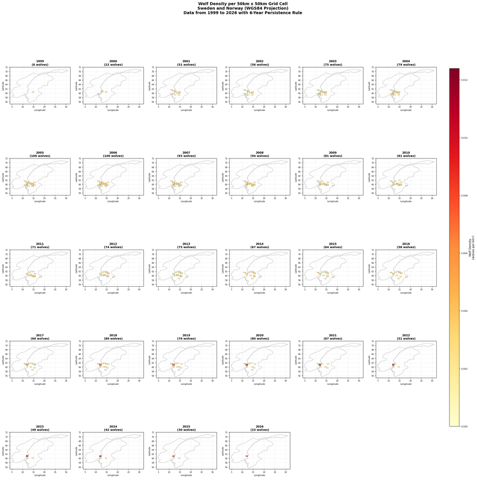

```python
# Figure size: adjust based on number of subplots
fig_width = n_cols * 4
fig_height = n_rows * 5

print(f"  Figure size: {fig_width} x {fig_height} inches")

fig, axes = plt.subplots(n_rows, n_cols, figsize=(fig_width, fig_height))

# Flatten axes array for easy iteration (handle case of single row/col)
if n_years == 1:
    axes = np.array([axes])
axes = axes.flatten()

# Set up colormap and normalization
cmap = plt.cm.YlOrRd  # Yellow-Orange-Red colormap (good for density)
norm = Normalize(vmin=0, vmax=max_density_overall)

print(f"  Colormap: YlOrRd (Yellow-Orange-Red)")
print(f"  Color scale: 0 to {max_density_overall:.6f} wolves/km²")

# Map extent (longitude, latitude bounds for Sweden and Norway)
lon_min, lon_max = 4, 32
lat_min, lat_max = 55, 72

print(f"  Map extent: Longitude {lon_min}° to {lon_max}°, Latitude {lat_min}° to {lat_max}°")


# =============================================================================
# STEP 9: PLOT EACH YEAR'S DATA
# =============================================================================
print("\n" + "-" * 100)
print("STEP 9: PLOTTING DATA FOR EACH YEAR")
print("-" * 100)

for idx, year in enumerate(sorted(years)):
    ax = axes[idx]
    grids = year_data[year]

    # Count grids with wolves for progress display
    grids_with_wolves = sum(1 for g in grids if g['wolf_density'] > 0)
    print(f"  Plotting {year}... ({grids_with_wolves} grids with wolves)")

    # Set map extent
    ax.set_xlim(lon_min, lon_max)
    ax.set_ylim(lat_min, lat_max)

    # Draw country outlines first (background)
    draw_country_outline(ax, SWEDEN_BORDER, color='darkgray', linewidth=0.8)
    draw_country_outline(ax, NORWAY_BORDER, color='darkgray', linewidth=0.8)

    # Plot each grid cell with wolves
    for grid in grids:
        density = grid['wolf_density']

        # Only plot grids with wolf density > 0
        if density > 0:
            # Get grid cell corners
            corners = get_grid_corners(grid['centroid_lat'], grid['centroid_lon'])

            # Create polygon
            polygon = mpatches.Polygon(
                corners,
                closed=True,
                facecolor=cmap(norm(density)),
                edgecolor='black',
                linewidth=0.3,
                alpha=0.8,
                zorder=2
            )
            ax.add_patch(polygon)

    # Set title and labels
    total_wolves = sum(g['wolf_pop'] for g in grids)
    ax.set_title(f'{year}\n({total_wolves} wolves)', fontsize=10, fontweight='bold')
    ax.set_xlabel('Longitude', fontsize=8)
    ax.set_ylabel('Latitude', fontsize=8)

    # Add gridlines
    ax.grid(True, linestyle='--', alpha=0.3, zorder=0)

    # Set aspect ratio to equal for proper geographic representation
    ax.set_aspect('equal', adjustable='box')

    # Reduce tick label size
    ax.tick_params(axis='both', labelsize=7)

# Hide empty subplots (if any)
for idx in range(n_years, len(axes)):
    axes[idx].axis('off')
    print(f"  Hiding empty subplot {idx + 1}")


# =============================================================================
# STEP 10: ADD COLORBAR
# =============================================================================
print("\n" + "-" * 100)
print("STEP 10: ADDING COLORBAR")
print("-" * 100)

# Create a ScalarMappable for the colorbar
sm = ScalarMappable(cmap=cmap, norm=norm)
sm.set_array([])

# Add colorbar to the figure
cbar_ax = fig.add_axes([0.92, 0.15, 0.02, 0.7])  # [left, bottom, width, height]
cbar = fig.colorbar(sm, cax=cbar_ax)
cbar.set_label('Wolf Density\n(wolves per km²)', fontsize=10)
cbar.ax.tick_params(labelsize=8)

print("  Colorbar added to the right side of the figure")


# =============================================================================
# STEP 11: ADD MAIN TITLE AND ADJUST LAYOUT
# =============================================================================
print("\n" + "-" * 100)
print("STEP 11: ADDING MAIN TITLE AND ADJUSTING LAYOUT")
print("-" * 100)

fig.suptitle('Wolf Density per 50km x 50km Grid Cell\nSweden and Norway (WGS84 Projection)\n'
             f'Data from {min(years)} to {max(years)} with 6-Year Persistence Rule',
             fontsize=14, fontweight='bold', y=0.98)

# Adjust layout to prevent overlap
plt.tight_layout(rect=[0, 0, 0.9, 0.95])

print("  Main title added")
print("  Layout adjusted to prevent overlap")


# =============================================================================
# STEP 12: SAVE THE FIGURE
# =============================================================================
print("\n" + "-" * 100)
print("STEP 12: SAVING THE FIGURE")
print("-" * 100)

print(f"  Saving to: {output_file}")
print("  DPI: 150")
print("  This may take a moment...")

plt.savefig(output_file, dpi=150, bbox_inches='tight', facecolor='white')

print("  Figure saved successfully!")


# =============================================================================
# STEP 13: DISPLAY SUMMARY
# =============================================================================
print("\n" + "=" * 100)
print("FINAL SUMMARY")
print("=" * 100)

print(f"""
  INPUT:
    Directory: {input_dir}
    Files processed: {len(distribution_files)}

  OUTPUT:
    Figure saved to: {output_file}
    Figure size: {fig_width} x {fig_height} inches at 150 DPI

  DATA SUMMARY:
    Years plotted: {min(years)} to {max(years)} ({n_years} years)
    Subplot layout: {n_rows} rows x {n_cols} columns
    Maximum wolf density: {max_density_overall:.6f} wolves/km²
    Maximum total wolves: {max_wolves_overall}

  METHODOLOGY:
    - Wolf density = Total pack sizes in grid / Grid area (2500 km²)
    - 6-year persistence rule applied to territory presence
    - Grid cells colored by wolf density (Yellow-Orange-Red scale)
    - Country boundaries shown for Sweden and Norway
""")

print("=" * 100)
print("Script completed successfully!")
print("=" * 100)


# =============================================================================
# STEP 14: SHOW THE PLOT (optional - comment out if running in batch mode)
# =============================================================================
# Uncomment the line below to display the plot interactively
# plt.show()
```